# Data Manipulation Techniques

2024-02-19

## In this excercise, various data manipulation techniques are displayed. We then use this refined data to perform a plot.

**NOTE**: *When viewing table metadata, only the first few rows are printed.*

To start, let’s consider the following data surrounding penguins, loaded into memory from a CSV.

```r
peng_data <- read.csv('W04-Penguins.csv')
knitr::kable(head(peng_data), caption = "Raw Penguins Data")
```

Raw Penguins Data

| X | species | island | bill_length_mm | bill_depth_mm | flipper_length_mm | body_mass_g | sex | year |
| --- | --- | --- | --- | --- | --- | --- | --- | --- |
| 1 | Adelie | Torgersen | 39.1 | 18.7 | 181 | 3750 | male | 2007 |
| 2 | Adelie | Torgersen | 39.5 | 17.4 | 186 | 3800 | female | 2007 |
| 3 | Adelie | Torgersen | 40.3 | 18.0 | 195 | 3250 | female | 2007 |
| 4 | Adelie | Torgersen | NA | NA | NA | NA | NA | 2007 |
| 5 | Adelie | Torgersen | 36.7 | 19.3 | 193 | 3450 | female | 2007 |
| 6 | Adelie | Torgersen | 39.3 | 20.6 | 190 | 3650 | male | 2007 |

It is often the case that a data set needs to be curated. This can include searching for rows with empty values and removing them. While many libraries perform this “under-the-hood”, here is an example of how we can manually remove all rows with any missing value.

```r
peng_clean <- peng_data[complete.cases(peng_data),]
knitr::kable(head(peng_clean), caption = "Cleaned Penguin Data", row.names = FALSE)
```

Cleaned Penguin Data

| X | species | island | bill_length_mm | bill_depth_mm | flipper_length_mm | body_mass_g | sex | year |
| --- | --- | --- | --- | --- | --- | --- | --- | --- |
| 1 | Adelie | Torgersen | 39.1 | 18.7 | 181 | 3750 | male | 2007 |
| 2 | Adelie | Torgersen | 39.5 | 17.4 | 186 | 3800 | female | 2007 |
| 3 | Adelie | Torgersen | 40.3 | 18.0 | 195 | 3250 | female | 2007 |
| 5 | Adelie | Torgersen | 36.7 | 19.3 | 193 | 3450 | female | 2007 |
| 6 | Adelie | Torgersen | 39.3 | 20.6 | 190 | 3650 | male | 2007 |
| 7 | Adelie | Torgersen | 38.9 | 17.8 | 181 | 3625 | female | 2007 |

Notice how **row 4** from the first CSV is now removed!

Moving forward, let’s filter the clean data based off values in the `species` column.

```r
peng_species <- peng_clean[peng_clean$species %in% c("Adelie", "Gentoo"), ]
```

In the above it is shown how the data set can be filtered to only species called `Adelie` and `Gentoo`. Since the first rows of the last two data sets are the same, let’s look at the length of the cleaned data vs the filtered data to validate anything happened.

Clean data size:

```
[1] 333
```

Filtered data size:

```
[1] 265
```

Success! We have removed some rows from the cleaned data set.

Let’s further remove rows to only include penguins from the `Biscoe` and `Torgersen` islands.

```r
peng_islands <- peng_species[peng_species$island %in% c("Biscoe", "Torgersen"), ]
```

Newly filtered data set size is:

```
[1] 210
```

Success! We have further filtered our data set to be 210 rows compared to the previous 265.

Furthermore, let’s refine our data to only include penguins with `body_mass_g` **less than 5000** grams but **more than 3500** grams. For this, we will use a library called `dplyr`.

```r
in_shape_pengs <- peng_islands %>% filter(body_mass_g > 3500 & body_mass_g < 5000)
knitr::kable(head(in_shape_pengs), caption = "Body Mass Penguin Data", row.names = FALSE)
```

Body Mass Penguin Data

| X | species | island | bill_length_mm | bill_depth_mm | flipper_length_mm | body_mass_g | sex | year |
| --- | --- | --- | --- | --- | --- | --- | --- | --- |
| 1 | Adelie | Torgersen | 39.1 | 18.7 | 181 | 3750 | male | 2007 |
| 2 | Adelie | Torgersen | 39.5 | 17.4 | 186 | 3800 | female | 2007 |
| 6 | Adelie | Torgersen | 39.3 | 20.6 | 190 | 3650 | male | 2007 |
| 7 | Adelie | Torgersen | 38.9 | 17.8 | 181 | 3625 | female | 2007 |
| 8 | Adelie | Torgersen | 39.2 | 19.6 | 195 | 4675 | male | 2007 |
| 14 | Adelie | Torgersen | 38.6 | 21.2 | 191 | 3800 | male | 2007 |

We can now see some example rows from the further filtered data. It looks to have successfully filtered out based off the value of `body_mass_g`.

Let’s perform some basic math operations on the `body_mass_g` column, while also renaming it to reflect the updated data.

```r
mutated_data <- in_shape_pengs %>%
  mutate(BMI = body_mass_g / 4000) %>%
  select(-body_mass_g) %>%
  select(-X) %>%
  select(-sex) %>%
  select(-year)

knitr::kable(head(mutated_data), caption = "Shortend BMI Penguin Data", row.names = FALSE)
```

Shortend BMI Penguin Data

| species | island | bill_length_mm | bill_depth_mm | flipper_length_mm | BMI |
| --- | --- | --- | --- | --- | --- |
| Adelie | Torgersen | 39.1 | 18.7 | 181 | 0.93750 |
| Adelie | Torgersen | 39.5 | 17.4 | 186 | 0.95000 |
| Adelie | Torgersen | 39.3 | 20.6 | 190 | 0.91250 |
| Adelie | Torgersen | 38.9 | 17.8 | 181 | 0.90625 |
| Adelie | Torgersen | 39.2 | 19.6 | 195 | 1.16875 |
| Adelie | Torgersen | 38.6 | 21.2 | 191 | 0.95000 |

Now BMI is displayed instead of `body_bass_g`, and in addition to that, we have dropped the `sex`, `year`, and `observation_id (X)` columns!

### Thoughts

To recap data manipulation, we have shown examples of extensive filtering based off various parameters. We can also see examples of how to handle the empty row results from a technical standpoint. However, we must remember that blatantly disregarding rows without carefully considering the impact on what your overall data set is attempting to convey could lead to misinformation.

## Data visualization

The following graph shows the flipper length vs bill length. We will use our most filtered dataset in the previous section to display these. The different species will be different colors, while the size of the individual data point is meant to be proportional to the `BMI` value.

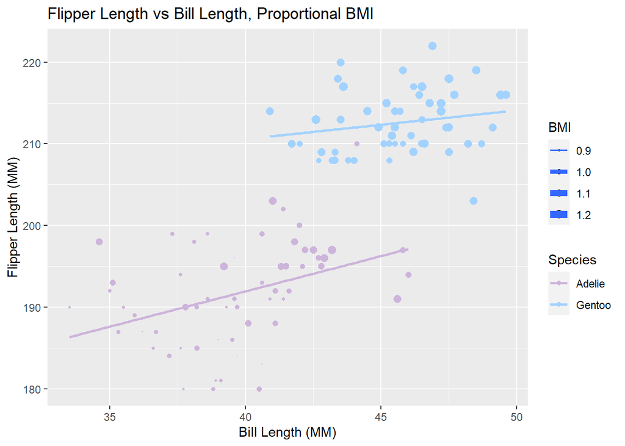

```r
library(ggplot2)

# Plot
gg <- ggplot(mutated_data, aes(x = bill_length_mm, y = flipper_length_mm, color = species, size = BMI)) +
  # As Scatter
  geom_point() +
  # With regression lines
  geom_smooth(method = "lm", se = FALSE, aes(group = species)) +
  # Label Accordingly +
  labs(x = "Bill Length (MM)", y ="Flipper Length (MM)", title="Flipper Length vs Bill Length, Proportional BMI") +
  # Set the colors based off species
  scale_color_manual(values = c("Adelie" = "#cdb4db", "Gentoo"="#a2d2ff")) +
  # Don't allow the scale to be too large.
  scale_size_continuous(range = c(0, 3)) +
  guides(color = guide_legend(title = "Species"), size = guide_legend(title = "BMI"))

print(gg)
```